# PRESENTED BY:

TAVLEEN KAUR  
RIDDHI HINDOCHA  
SECTION: 02

```python
from google.colab import drive
drive.mount('/content/drive')
```

# FACE RECOGNITION

Face recognition is a technology that identifies or verifies individuals by analyzing and comparing patterns based on facial features. It has a wide range of applications, from security systems and law enforcement to personal devices and social media platforms.  
REFERENCE FOR CODE

# DATASET COLLECTION

To train these models we have used two different datasets- the positive dataset and the negative dataset.  
The Positive dataset is further divided into Tavleen's dataset(having images of Tavleen) and Riddhi's dataset(having images of Riddhi.

- Negative dataset is retrieved from KAGGLE.
- The positive dataset has been created manually.

# IMPORT NECESSARY LIBRARIES

```python
import pandas as pd
import glob
from sklearn.model_selection import train_test_split
import matplotlib.pyplot as plt
import numpy as np
import tensorflow as tf
from tensorflow.keras.applications import VGG16
from tensorflow.keras.models import Sequential, Model
from tensorflow.keras.layers import Dense, Flatten, Dropout, Input, Conv2D, Lambda, Concatenate
from tensorflow.keras.optimizers import Adam
from tensorflow.keras.callbacks import ModelCheckpoint, EarlyStopping
import os
import random
from tensorflow.keras.preprocessing.image import load_img, img_to_array
from tensorflow.keras.utils import to_categorical
from tensorflow.keras import backend as K
from keras.preprocessing.image import ImageDataGenerator
```

# VGG 16 MODEL

VGG16 is a deep learning model architecture primarily designed for image classification tasks. It comprises multiple convolutional layers followed by max-pooling layers for feature extraction, and fully connected layers for classification.  
It is widely used as a pre-trained model for various computer vision tasks, including image classification, object detection, and feature extraction.

## DATA LOADING AND PREPROCESSING FOR VGG 16 MODEL

```python
# Create dataframes containing file paths and labels
df_face1 = pd.DataFrame({'file_path': glob.glob('/content/drive/MyDrive/PersonalDataset/Riddhi/*.jpg'), 'label': 'Riddhi'})
df_face2 = pd.DataFrame({'file_path': glob.glob('/content/drive/MyDrive/PersonalDataset/Tavleen/*.jpg'), 'label': 'Tavleen'})
df_negative = pd.DataFrame({'file_path': glob.glob('/content/drive/MyDrive/PersonalDataset/NEGATIVE/*.jpg'), 'label': 'NEGATIVE'})

# Combine dataframes
df = pd.concat([df_face1, df_face2, df_negative], ignore_index=True)

# Shuffle dataframe
df = df.sample(frac=1).reset_index(drop=True)

image_size = (100,100)
batch_size = 8
# Create ImageDataGenerator
train_datagen = ImageDataGenerator(
    rescale=1./255,
)

# Load images from dataframe
train_generator = train_datagen.flow_from_dataframe(
    dataframe=df,
    x_col='file_path',
    y_col='label',
    target_size=image_size,
    batch_size=batch_size,
    class_mode='categorical',  # Categorical classification
    shuffle=True
)
```

```
Found 90 validated image filenames belonging to 3 classes.
```

```python
# Split the dataset into train and test sets
train_df, test_df = train_test_split(df, test_size=0.2, random_state=42)

# Split the train set into train and validation sets
train_df, val_df = train_test_split(train_df, test_size=0.2, random_state=42)

# Create ImageDataGenerators for train, test, and validation sets
train_generator = train_datagen.flow_from_dataframe(
    dataframe=train_df,
    x_col='file_path',
    y_col='label',
    target_size=image_size,
    batch_size=batch_size,
    class_mode='categorical',  # Categorical classification
    shuffle=True
)

test_generator = train_datagen.flow_from_dataframe(
    dataframe=test_df,
    x_col='file_path',
    y_col='label',
    target_size=image_size,
    batch_size=batch_size,
    class_mode='categorical',
    shuffle=False  # No need to shuffle the test set
)

val_generator = train_datagen.flow_from_dataframe(
    dataframe=val_df,
    x_col='file_path',
    y_col='label',
    target_size=image_size,
    batch_size=batch_size,
    class_mode='categorical',
    shuffle=True  # Shuffle the validation set
)
```

```
Found 57 validated image filenames belonging to 3 classes.
Found 18 validated image filenames belonging to 3 classes.
Found 15 validated image filenames belonging to 3 classes.
```

# EXPLORATORY DATA ANALYSIS

[figure not shown]

```python
# Function to plot samples from train_generator with class names
def plot_samples_with_class_names(generator, class_names, num_samples=5):
    plt.figure(figsize=(15, 5))
    for i in range(num_samples):
        # Get a batch of images and labels from the generator
        images, labels = generator.next()
        # Map numeric labels to class names
        class_labels = [class_names[np.argmax(label)] for label in labels]
        # Plot each image with its corresponding class name
        plt.subplot(1, num_samples, i + 1)
        plt.imshow(images[0])
        plt.title(f'Class: {class_labels[0]}')
        plt.axis('off')
    plt.show()

# Get class names
class_names = list(train_generator.class_indices.keys())

# Plot samples from train_generator with class names
plot_samples_with_class_names(train_generator, class_names, num_samples=6)
```

```
{'NEGATIVE': 16, 'Riddhi': 23, 'Tavleen': 18}
```

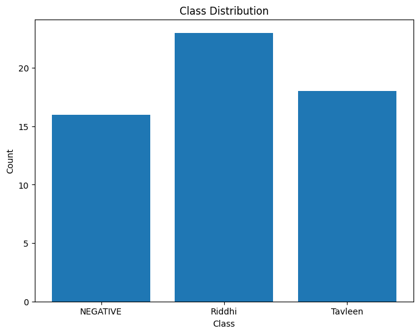

```python
# Function to plot class distribution
def plot_class_distribution(generator):
    # Get class names and their corresponding indices
    class_names = list(generator.class_indices.keys())
    class_indices = generator.class_indices

    # Initialize a dictionary to store class counts
    class_counts = {class_name: 0 for class_name in class_names}

    # Iterate over batches of data to count the occurrences of each class
    for _ in range(len(generator)):
        _, labels = generator.next()
        for label in labels:
            class_counts[class_names[np.argmax(label)]] += 1

    print(class_counts)
    # Plot class distribution
    plt.figure(figsize=(8, 6))
    plt.bar(class_counts.keys(), class_counts.values())
    plt.xlabel('Class')
    plt.ylabel('Count')
    plt.title('Class Distribution')
    plt.show()

# Plot class distribution
plot_class_distribution(train_generator)
```

```
{'NEGATIVE': 6, 'Riddhi': 7, 'Tavleen': 5}
```

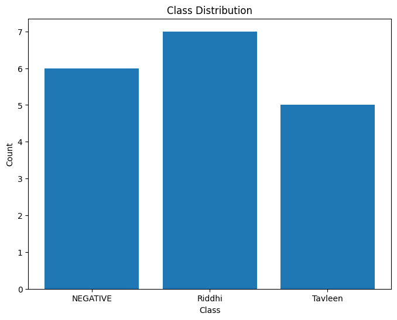

```python
plot_class_distribution(test_generator)
```

```
{'NEGATIVE': 5, 'Riddhi': 4, 'Tavleen': 6}
```

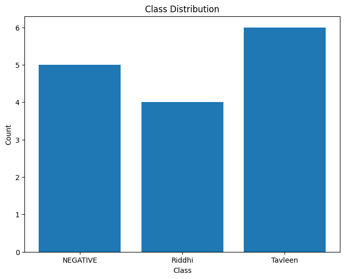

```python
plot_class_distribution(val_generator)
```

```
Image Sizes:
  Min Height: 100
  Max Height: 100
  Min Width: 100
  Max Width: 100
```

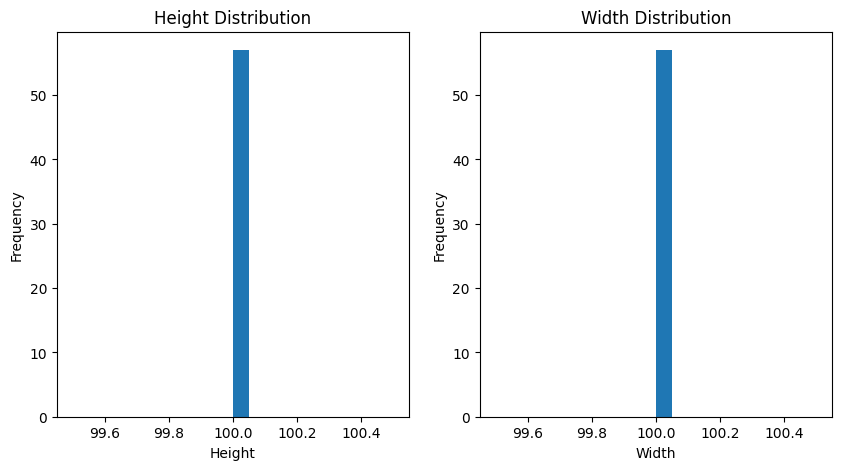

```python
# Function to compute and plot image statistics
def plot_image_statistics(generator):
    image_sizes = []
    for _ in range(len(generator)):
        images, _ = generator.next()
        for image in images:
            image_sizes.append(image.shape[:2])
    image_sizes = np.array(image_sizes)
    print("Image Sizes:")
    print("  Min Height:", image_sizes[:, 0].min())
    print("  Max Height:", image_sizes[:, 0].max())
    print("  Min Width:", image_sizes[:, 1].min())
    print("  Max Width:", image_sizes[:, 1].max())

    plt.figure(figsize=(10, 5))
    plt.subplot(1, 2, 1)
    plt.hist(image_sizes[:, 0], bins=20)
    plt.xlabel('Height')
    plt.ylabel('Frequency')
    plt.title('Height Distribution')

    plt.subplot(1, 2, 2)
    plt.hist(image_sizes[:, 1], bins=20)
    plt.xlabel('Width')
    plt.ylabel('Frequency')
    plt.title('Width Distribution')

    plt.show()

# Plot image statistics
plot_image_statistics(train_generator)
```

## INSIGHTS ON DATASET

The dataset consists of images of three classes: NEGATIVE, Riddhi, and Tavleen. The distribution of images across the train, test, and validation sets is as follows:

|  | NEGATIVE | Riddhi | Tavleen |
| --- | --- | --- | --- |
| Train | 16 | 23 | 18 |
| Test | 6 | 7 | 5 |
| Val | 5 | 4 | 6 |

In total, there are 90 images in the dataset, with each class having a varying number of images in each set.

The images in the dataset have consistent sizes, with a minimum height and width of 100 pixels and a maximum height and width of 100 pixels.

The dataset has been split into training, validation, and test sets for model training and evaluation purposes.

## TRAIN VGG 16 MODEL

```python
# Load the pre-trained VGG16 model without the top (fully connected) layers
base_model = VGG16(weights='imagenet', include_top=False, input_shape=(100, 100, 3))

# Freeze the convolutional base
base_model.trainable = False

# Create a new model on top of the pre-trained base model
model = Sequential([
    base_model,
    Flatten(),
    Dense(256, activation='relu'),
    Dropout(0.5),
    Dense(3, activation='softmax')  # 3 output classes: Riddih, Tavleen, Negative
])

# Compile the model with F1-score metric
model.compile(optimizer=Adam(learning_rate=0.0001),
              loss='categorical_crossentropy',
              metrics=['accuracy'])

# Display the model summary
model.summary()
```

```
Downloading data from https://storage.googleapis.com/tensorflow/keras-applications/vgg16/vgg16_weights_tf_dim_ordering_tf_kernels_notop.h5
Model: "sequential"
_________________________________________________________________
 Layer (type)                Output Shape              Param #
=================================================================
 vgg16 (Functional)          (None, 3, 3, 512)         14714688

 flatten (Flatten)           (None, 4608)              0

 dense (Dense)               (None, 256)               1179904

 dropout (Dropout)           (None, 256)               0

 dense_1 (Dense)             (None, 3)                 771

=================================================================
Total params: 15895363 (60.64 MB)
Trainable params: 1180675 (4.50 MB)
Non-trainable params: 14714688 (56.13 MB)
_________________________________________________________________
```

```python
# Define callbacks
checkpoint = ModelCheckpoint("best_vgg16_model.h5", monitor='val_accuracy', verbose=1, save_best_only=True, mode='max')
early_stopping = EarlyStopping(monitor='val_loss', patience=3, verbose=1, restore_best_weights=True)


# Train the model
history = model.fit(train_generator,
                    steps_per_epoch=len(train_generator),
                    epochs=3,
                    validation_data=val_generator,
                    validation_steps=len(val_generator),
                    callbacks=[checkpoint, early_stopping])
```

```
Epoch 1: val_accuracy improved from -inf to 0.66667, saving model to best_vgg16_model.h5
```

```
Epoch 2: val_accuracy improved from 0.66667 to 1.00000, saving model to best_vgg16_model.h5
Epoch 3: val_accuracy did not improve from 1.00000
```

```python
# Evaluate the model on the test set
test_metrics = model.evaluate(test_generator, steps=len(test_generator))
test_loss = test_metrics[0]
test_metrics_values = test_metrics[1:]  # Extract metric values except for the loss

print("VGG16 Evaluation")
# Print test loss
print('Test loss:', test_loss)

# Print other metrics
for metric_name, metric_value in zip(model.metrics_names[1:], test_metrics_values):
    print(f'Test {metric_name}: {metric_value}')
```

```
VGG16 Evaluation
Test loss: 0.08603242039680481
Test accuracy: 1.0
```

## VGG 16 MODEL INSIGHTS

- **Architecture:**
  - The model consists of a Sequential architecture with layers including VGG16, Flatten, Dense, and Dropout.
  - VGG16 is used as a feature extractor with non-trainable parameters.
- **Training Performance:**
  - During training, the model achieved an accuracy of 100% on the training data.
  - The model showed improvement in validation accuracy from 0.6666 to 1.0 over the epochs.
  - The final validation accuracy reached 1.0 after the third epoch.
- **Testing Performance:**
  - Evaluation on the test dataset resulted in a loss of 0.0860 and an accuracy of 100%.
- **Model Size:**
  - The total number of parameters in the model is 15,895,363, with 1,180,675 trainable parameters and 14,714,688 non-trainable parameters from VGG16.
- **Training Time:**
  - Each epoch took approximately 14 seconds for training.
- **Model Save:**
  - The best model with the highest validation accuracy was saved to `best_vgg16_model.h5`.

# SIAMESE NETWORKS

Siamese networks are a type of neural network architecture designed for tasks involving similarity or dissimilarity measurement between pairs of inputs.  
**WORKING:**

- Siamese networks are composed of two identical subnetworks that accept two input samples simultaneously.
- Each input sample is processed independently through its respective subnetwork to extract meaningful feature representations.
- After feature extraction, the output embeddings (vectors) from both subnetworks are compared to measure the similarity or dissimilarity between the input samples.

## DATA PREPARATION FOR SIAMESE NETWORKS

```python
# Define data directories
positive_folder_1 = '/content/drive/MyDrive/PersonalDataset/Riddhi'
positive_folder_2 = '/content/drive/MyDrive/PersonalDataset/Tavleen'
negative_folder = '/content/drive/MyDrive/PersonalDataset/NEGATIVE'

# Function to load images from a folder
def load_images_from_folder(folder):
    images = []
    for filename in os.listdir(folder):
        img = load_img(os.path.join(folder, filename), target_size=(100, 100))
        img = img_to_array(img) / 255.0  # Normalize the pixel values
        images.append(img)
    return np.array(images)

# Load images from positive and negative folders
positive_images_1 = load_images_from_folder(positive_folder_1)
positive_images_2 = load_images_from_folder(positive_folder_2)
negative_images = load_images_from_folder(negative_folder)

# Function to create pairs of images with labels
def create_pairs(positive_images_1, positive_images_2, negative_images, num_pairs):
    pairs = []
    labels = []

    # Create positive pairs
    for i in range(num_pairs):
        idx_1 = random.randint(0, len(positive_images_1) - 1)
        idx_2 = random.randint(0, len(positive_images_1) - 1)
        pairs.append([positive_images_1[idx_1], positive_images_1[idx_2]])
        # Label 1 for positive pairs
        labels.append(1)
        pairs.append([positive_images_2[idx_1], positive_images_2[idx_2]])
        labels.append(1)

    # Create negative pairs
    for i in range(num_pairs):
        idx_1 = random.randint(0, len(negative_images) - 1)
        idx_2 = random.randint(0, len(negative_images) - 1)
        pairs.append([positive_images_1[idx_1], negative_images[idx_2]])
        # Label 0 for negative pairs
        labels.append(0)
        pairs.append([positive_images_2[idx_1], negative_images[idx_2]])
        labels.append(0)
        pairs.append([positive_images_1[idx_1], positive_images_2[idx_2]])
        labels.append(0)


    return np.array(pairs), np.array(labels)

# Create pairs of images and their labels
num_pairs = min(len(positive_images_1), len(negative_images))
pairs, labels = create_pairs(positive_images_1, positive_images_2, negative_images, num_pairs)

# Shuffle the pairs and labels
indices = np.arange(len(pairs))
np.random.shuffle(indices)
pairs = pairs[indices]
labels = labels[indices]

# Split the dataset into train, validation, and test sets
train_val_split = int(0.8 * len(pairs))
val_test_split = int(0.9 * len(pairs))

train_pairs, train_labels = pairs[:train_val_split], labels[:train_val_split]
val_pairs, val_labels = pairs[train_val_split:val_test_split], labels[train_val_split:val_test_split]
test_pairs, test_labels = pairs[val_test_split:], labels[val_test_split:]
```

## TRAIN A BASIC SIAMESE NETWORK

```python
# Define the Siamese network model
def siamese_network(input_shape):
    # Define the input tensors for the two input images
    input_a = Input(shape=input_shape)
    input_b = Input(shape=input_shape)

    # Define the CNN model (shared weights) for feature extraction
    model = Conv2D(32, (3, 3), activation='relu')
    x1 = model(input_a)
    x2 = model(input_b)

    # Flatten the output from the CNN
    x1 = Flatten()(x1)
    x2 = Flatten()(x2)

    # Calculate the Euclidean distance between the output embeddings
    distance = Lambda(lambda tensors: K.abs(tensors[0] - tensors[1]))([x1, x2])

    # Define the final output layer
    outputs = Dense(1, activation='sigmoid')(distance)

    # Build the Siamese network model
    siamese_model = Model(inputs=[input_a, input_b], outputs=outputs)

    return siamese_model

# Define input shape (assuming images are grayscale with size 100x100)
input_shape = (100, 100, 3)

# Create the Siamese network model
model1 = siamese_network(input_shape)

# Compile the model
model1.compile(optimizer=Adam(learning_rate=0.0001), loss='binary_crossentropy', metrics=['accuracy'])

# Display the model summary
model1.summary()
```

```
Model: "model"
__________________________________________________________________________________________________
 Layer (type)                Output Shape                 Param #   Connected to
==================================================================================================
 input_2 (InputLayer)        [(None, 100, 100, 3)]        0         []

 input_3 (InputLayer)        [(None, 100, 100, 3)]        0         []

 conv2d (Conv2D)             (None, 98, 98, 32)           896       ['input_2[0][0]',
                                                                     'input_3[0][0]']

 flatten_1 (Flatten)         (None, 307328)               0         ['conv2d[0][0]']

 flatten_2 (Flatten)         (None, 307328)               0         ['conv2d[1][0]']

 lambda (Lambda)             (None, 307328)               0         ['flatten_1[0][0]',
                                                                     'flatten_2[0][0]']

 dense_2 (Dense)             (None, 1)                    307329    ['lambda[0][0]']

==================================================================================================
Total params: 308225 (1.18 MB)
Trainable params: 308225 (1.18 MB)
Non-trainable params: 0 (0.00 Byte)
__________________________________________________________________________________________________
```

```python
# Define a callback to save the best model
checkpoint_filepath = 'basic_saimese_model.h5'
model_checkpoint_callback = ModelCheckpoint(
    filepath=checkpoint_filepath,
    monitor='val_loss',
    mode='min',
    save_best_only=True,
    save_weights_only=False,
    verbose=1
)

# Train the model with callbacks
history1 = model1.fit(
    [train_pairs[:, 0], train_pairs[:, 1]],
    train_labels,
    batch_size=batch_size,
    epochs=3,
    validation_data=([val_pairs[:, 0], val_pairs[:, 1]], val_labels),
    callbacks=[model_checkpoint_callback]
)
```

```
Epoch 1: val_loss improved from inf to 0.42550, saving model to basic_saimese_model.h5
Epoch 2: val_loss improved from 0.42550 to 0.27263, saving model to basic_saimese_model.h5
Epoch 3: val_loss improved from 0.27263 to 0.17925, saving model to basic_saimese_model.h5
```

```python
# Evaluate the model on the test set
print("Basic Saimese Evaluation")
test_loss, test_acc = model1.evaluate([test_pairs[:, 0], test_pairs[:, 1]], test_labels, verbose=0)
print(f'Test Loss: {test_loss}, Test Accuracy: {test_acc}')
```

```
Basic Saimese Evaluation
Test Loss: 0.09357254952192307, Test Accuracy: 1.0
```